# Conditions for Digital Innovation

Session 2.1

Prof. Bodong Chen

cbd@upenn.edu

Penn GSE

March 22, 2024

# Agenda

- What’s happening in the field?
- Upcoming Assignment: Design Project
- Conditions for Digital Innovation: People
  - Mini lecture
  - Group Work
- BREAK
- Lightning Talks #1
- Conditions for Digital Innovation: Artifacts, Tools
  - Mini lecture
  - Group Work
- BREAK
- Lightning Talks #2
- Plenary Discussion

# What’s happening in the field?

[Video](https://youtu.be/fjHtjT7GO1c?si=9ixtRHTUTtv3gKv6)

## you.com

[figure not shown]

## you.com

### (cont’d)

[figure not shown]

## “Why Chatbots Are Not the Future”

### By Amelia Wattenberger ([link](https://wattenberger.com/thoughts/boo-chatbots?utm_source=pocket_saves))

- Text inputs have no affordances
- Prompts are just a pile of context
- Responses are isolated
- The implementation—evaluation loop (is lengthy)

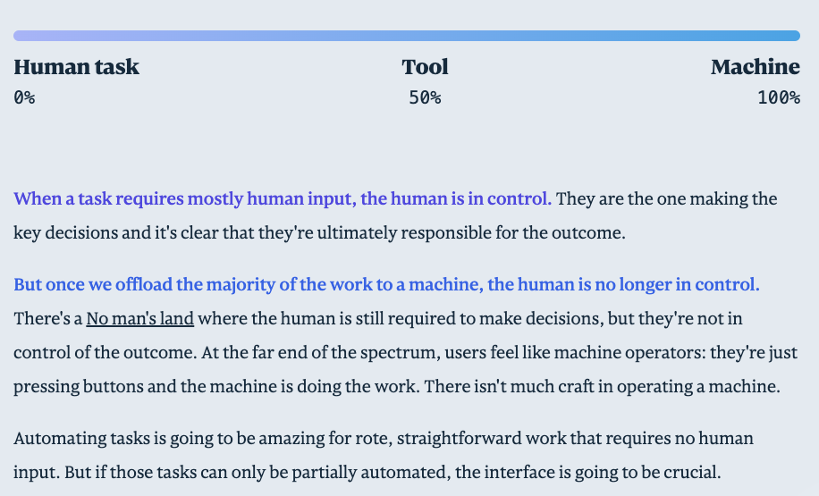

# What’s on your radar?

# Upcoming Assignment: Design Project

Assessment components

- Participation (30%)
- Bio Sketch & Reflection (20%)
- Artifact/Innovation Analysis (10%)
- Design Project (40%)
- Awareness and inspiration
- Views on learning
- Innovations “in the wild”
- Design an innovation for learning

## Upcoming Assignment: Design Project

### Description

- For your final project you will design a multi-faceted digital innovation for a learning context of your choice. This is an opportunity to envision and enact your views on learning and how it can be supported by digital innovation.
- Your project needs to address an enduring problem in education.
- Your project needs to have a digital innovation component – which can be broadly defined – and has a clear plan of engaging stakeholders.
- There is no page limit on the final document and you can use multimedia formats (e.g., interactive demo, story map, audiovisual essay) – so long as it contains key components of your design project (more details below).

## Upcoming Assignment: Design Project

### Key components

- Description of the context,
- Problem statement (current status and gaps),
- Perspectives on learning,
- Proposed digital innovation, and
- Plans of engaging stakeholders at different stages of the innovation

## Upcoming Assignment: Design Project

### Dates and milestones

- April 12: Submit a draft document with key components
- April 19: Share work-in-progress design solution with peers
- May 10: Final design project due

# Conditions for Digital Innovation for Learning

# Factors in the System: **People**, Artifacts, Tools

Anchor texts:

- Teachers as agents of change (Ertmer & Ottenbreit-Leftwich, 2010)
- Salient factors affecting technology innovations (Zhao et al., 2002)

## Teachers

### Problems facing teachers

- Teachers use roughly the same tools
- Teachers’ use of technology are rarely linked to student outcomes
- Technology use is typically not linked with powerful pedagogies but traditional instruction
- Teacher PD always lags behind

## Teacher change for technology integration

### Knowledge

TPACK – technological, pedagogical, and content knowledge

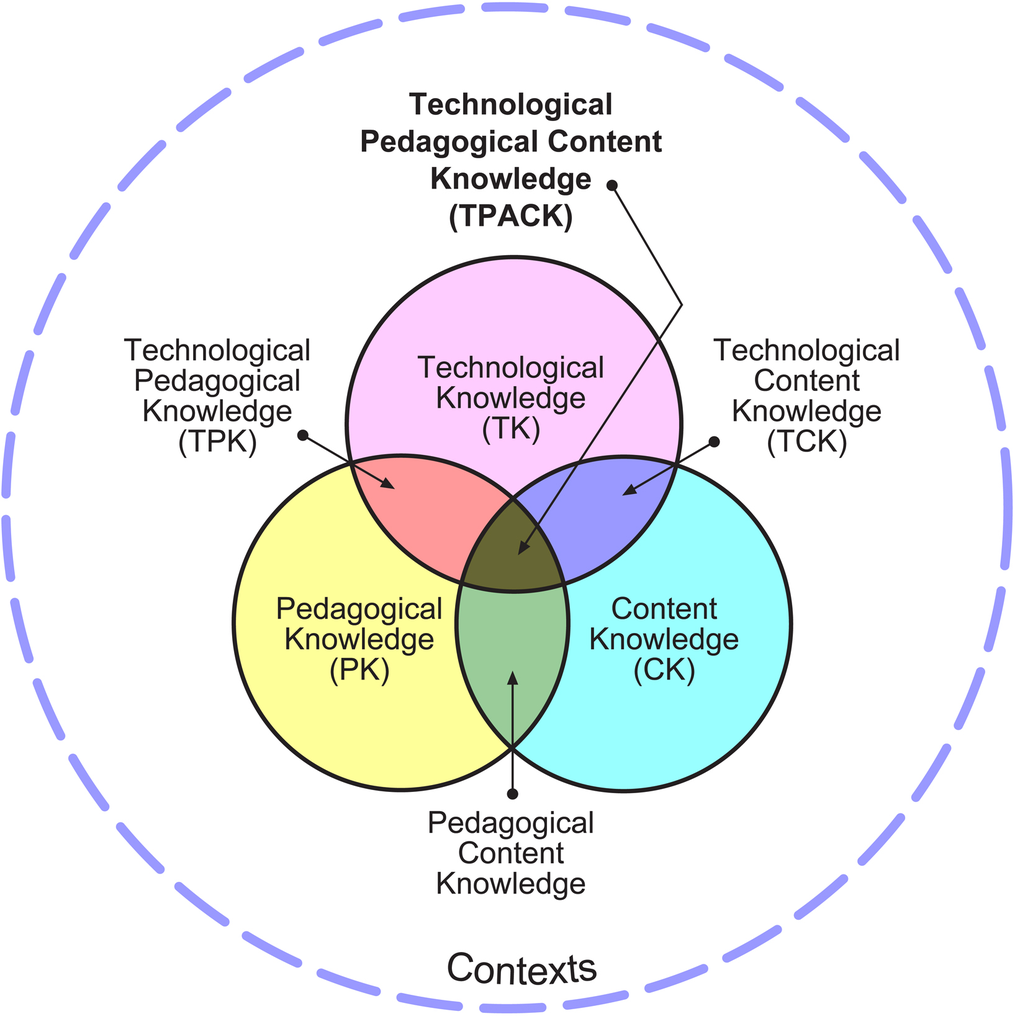

## Teacher change for technology integration

### Self-efficacy & Pedagogical Beliefs

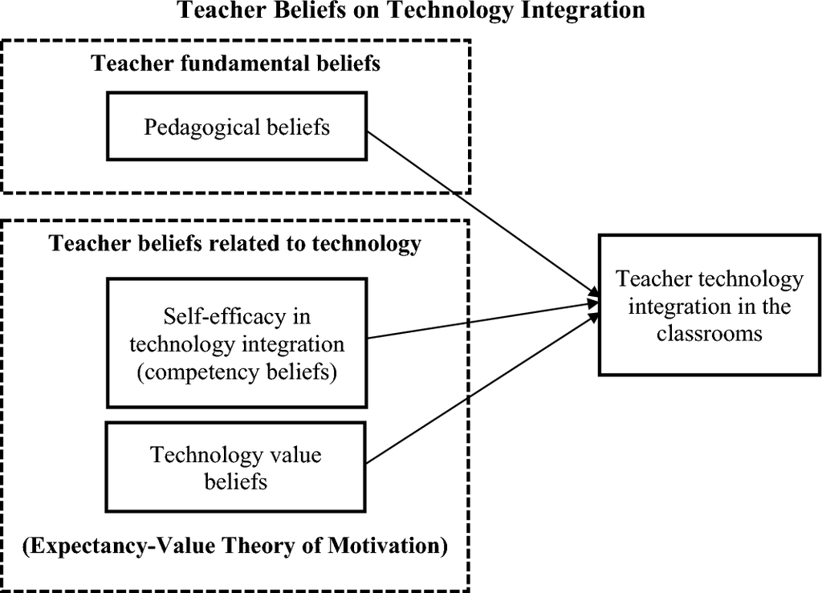

<sup>1</sup>

[^1]: Cheng, L., Antonenko, P. D., & Ritzhaupt, A. D. (2024). The impact of teachers’ pedagogical beliefs, self-efficacy, and technology value beliefs on 3D printing integration in K-12 science classrooms. Educational Technology Research and Development, 72(1), 181–208. https://doi.org/10.1007/s11423-023-10276-3

## Teacher change for technology integration

### Pedagogical Beliefs

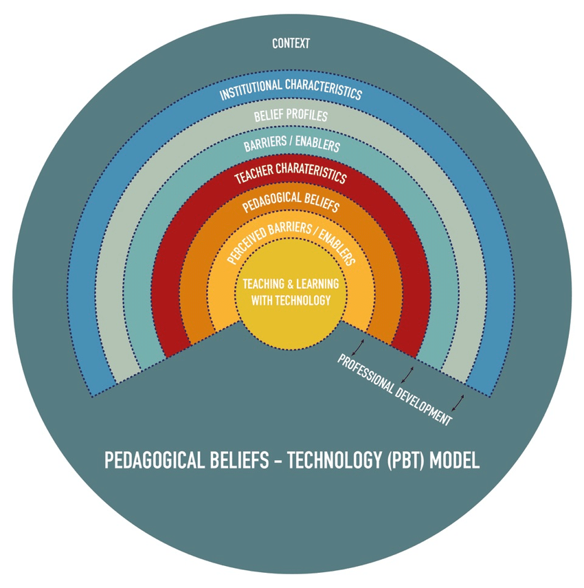

<sup>1</sup>

[^2]: Tondeur, J., van Braak, J., Ertmer, P. A., & Ottenbreit-Leftwich, A. (2017). Understanding the relationship between teachers’ pedagogical beliefs and technology use in education: A systematic review of qualitative evidence. Educational Technology Research and Development, 65(3), 555–575. https://doi.org/10.1007/s11423-016-9481-2

## Conditions

### The Innovation, Innovator, and Context

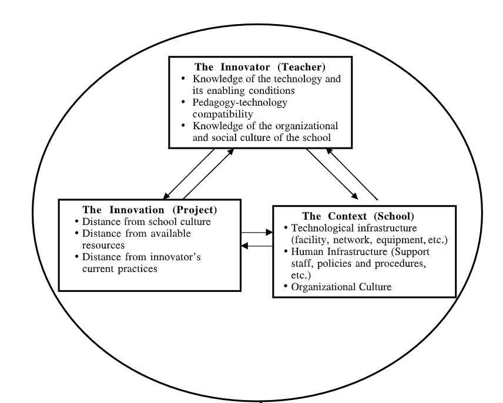

## The Innovation

- Distance from school culture
- Distance from existing practice
- Distance from available technological resources
- Dependence on others (people)
- Dependence on technological resources

## The Context

- Human infrastructure
- Technological infrastructure
- Social support

## Tech innovations in informal settings

### Libraries

[figure not shown]

## Tech innovations in informal settings

### Libraries

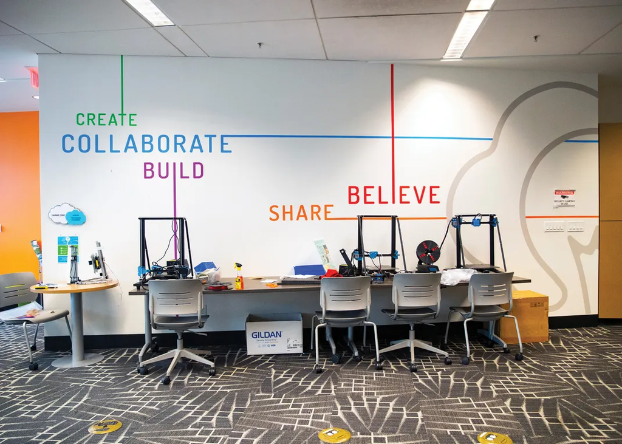

## Tech innovation in informal settings

### Museums

[figure not shown]

## Group Discussion

Choose one specific digital innovation your table is interested in.

Discuss:

1. Who are the main agents of change (e.g., teachers, librians)?
2. How far is the distance between the innovation and existing practice?
3. What support the change agents would need to effectively incorporate the innnovation?

Record your ideas on FigJam: https://bit.ly/eden-jam-2403  
(Password: eden)

# Lightning Talks: Panel #1

[Google Slides](https://docs.google.com/presentation/d/1DUa5ShgZGcKd_HTpHakhRBkruRbsPW3IWXwhRGe_r4M/edit#slide=id.p)

# Factors in the System: People, **Artifacts, Tools**

Anchor text: Roschelle et al. (1999)

## Software Components, End-user Programming

### A Dilemma

- Developers lack the contact hours with students to directly create excellent educational software
- Educators are not efﬁcient producers of educational software

## Software Components, End-user Programming

### Their Vision

> In the future, ideas for speciﬁc educational activities will be turned into software as easily as writing a document: The development process will be replaced by a process of editing, creating, and manipulating “editable applications.” Such applications will consist of high-level computational objects that are available as tangible building blocks.

## Software Components, End-user Programming

### Levers

- Support user programming for just-in-time adaptation of components
- Provide cognitive support for educators to manage wiring complexity

## Software Components, End-user Programming

### Then

> In JavaBeans (like many other component models), components interoperate by being “wired” together; wires specify the paths along which data and control can ﬂow.

### Now

> In GPTs (like many other component models), components interoperate by being “wired” together; wires specify the paths along which data and control can ﬂow.

## Let’s Talk “Wiring”

- What’s involved in this kind of wiring – of JavaBeans, GPTs, different tech tools?
- Wiring based on what?
- Who is in the position to do the wiring?
- What support do they need?

## New Types of Teacher Knowledge

TPACK in the age of ChatGPT and GenAI<sup>1</sup>

> “GenAI requires a philosophical shift in TPACK from viewing technology as a tool to recognizing the emergent, reciprocal dance between users and technologies like GenAI.”

> “Contextual Knowledge (XK) must expand in scope. While XK traditionally focuses on constraints within school systems, it must now also consider broader personal, cultural, political, and ethical implications of AI over decades-long timescales. These include impacts on notions of truth, trust in institutions, mental health, and workforce disruption that schools will need to address.”
[^3]: Mishra, P, Warr, M, & Islam, R. (2023). TPACK in the age of ChatGPT and Generative AI. *Journal of Digital Learning in Teacher Education*. https://punyamishra.com/2023/08/22/tpack-in-the-age-of-chatgpt-and-generative-ai/

## New Types of Relationship

### Trustworthy AI Engages Humans as Partners

Issues for human-AI partnership in education:

1. Comprehension – a shared human-AI understanding of learning as a phenomenon
2. Communication – the ability for human and AI partners to discuss this understanding of learning in relation to particular learners in real time
3. Co-decision and coordination – engaging human and AI partners to make collaborative decisions

Tong, J. R., & Lee, T. X. (2023). Trustworthy AI That Engages Humans as Partners in Teaching and Learning. *Computer, 56*(5), 62–73. https://doi.org/10.1109/MC.2023.3234517

## AI & E: 2024 AI Summit [Dr. June Ahn Spark Talk](https://youtu.be/bNZBfB0pQ-Y?si=9foLQCCRHURBTbuB)

[video not shown]

## Group Discussion

Choose one or two specific digital learning trends your table is interested in.

Discuss:

1. What specific *intentions* for education are valued or amplified? What *intentions* could/should be valued more?
2. How do “users” and “developers” interact with each other, if at all? How can you characterise their relationship?
3. How may “users” be empowered to contribute to the inonvation?

Record your ideas on FigJam: https://bit.ly/eden-jam-2403  
(Password: eden)

# Lightning Talks: Panel #2

[Google Slides](https://docs.google.com/presentation/d/1DUa5ShgZGcKd_HTpHakhRBkruRbsPW3IWXwhRGe_r4M/edit#slide=id.p)

# Plenary Discussion

EDEN 5050